# Craft Beer Study

Steve Bramhall, Lei Jiang

October 19, 2018

### INTRODUCTION

#### The following presentation is a result of a study on U.S. craft beers. A data set for 2410 craft beers and a data set for 558 breweries were merged and used to provide interesting insights. Discussions include the analysis and code methods used in the analysis. The following objectives were addressed in the study.

1. How many breweries are present in each state?
2. Merge beer data with the breweries data. Print the first 6 observations and the last six observations to check the merged file.
3. Report the number of NA’s in each column.
4. Compute the median alcohol content and international bitterness unit for each state. Plot a bar chart to compare.
5. Which state has the maximum alcohol (ABV) beer? Which state has the most bitter (IBU) beer?
6. Summary statistics for the ABV variable.
7. Is there an apparent relationship between the bitterness of the beer and its alcoholic content? Draw a scatter plot.

#### First the two data sets are read into data frames beerDF and breweryDF from csv files. An RStudio project was created so the team could reference their own local Github working directory. The columns (variables) of each data frame were custom named to be more readable and to provide a handle to merge the data later.

```r
# Read beer data from csv file and put into breweryDF data frame.Then rename columns to be more readable.
beerDF <- read.csv(".\\ImportFiles\\Beers.csv",header=TRUE,sep=",",stringsAsFactors = TRUE, encoding = "UTF-8")
names(beerDF) <- c("BeerName","BeerID","AlcoholByVolume","BitternessUnits","BreweryID",
                   "BeerStyle","Ounces") # rename table columns

# Read brewery data from csv file and put into breweryDF data frame.Then rename columns to be more readable.
breweryDF <- read.csv(".\\ImportFiles\\Breweries.csv",header=TRUE,sep=",",stringsAsFactors = FALSE)
names(breweryDF) <- c("BreweryID","BreweryName","City","State") # rename table columns
```

#### **Objective 1:** The number of breweries were grouped by state using the dplyr library function group_by. The summary of the grouped data was put into data frame brewerySummaryDF. The data frame makes it easier to work with in ggplot. ggplot was used to build Figure 1, a histogram of the brewery counts for each state. Washington DC is included with the states even though it’s not technically a state. The plot has a gradient color scheme, is sorted from least to most breweries and each state has the brewery count next to their bar. The plot was turned horizontally and the state abbreviations were scaled down to make it easier to read.

#### Colorado has the most breweries and this may not be a surprise since Coors and Anheuser-Busch (Budweiser) are located there. West Virginia, the Dakotas, and DC each only have 1 craft brewery.

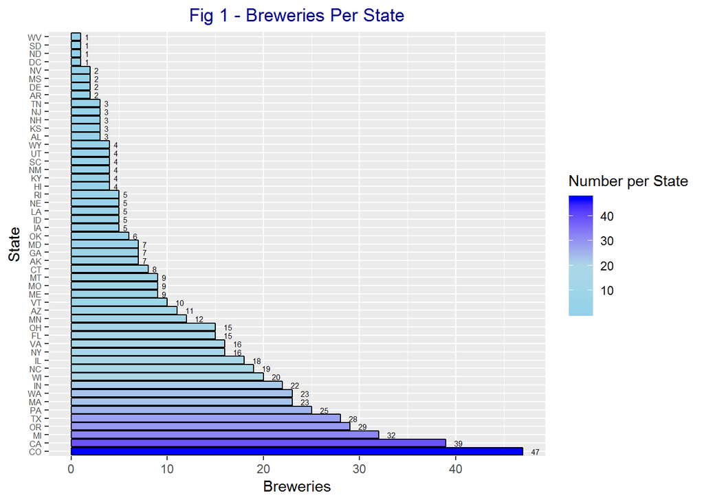

```r
#Obtain number of breweries in each state using group_by function in library dplyr
breweryStateCnt <- group_by(breweryDF,State)                   # group brewery count by state
brewerySummaryDF <- summarize(breweryStateCnt,count=n())       # put data into a df for easier manipulation

#create a histogram for df above called Figure 1;
ggplot(data=brewerySummaryDF, aes(x=reorder(State,-count), y=count)) +
  geom_histogram(stat="identity", col="black", aes(fill=count)) + coord_flip()+        # make horizontal plot
  theme(axis.text.y=element_text(size=6)) +                                            # decrease axis font
  labs(title = "Fig 1 - Breweries Per State",x="State",y="Breweries") +                # add axes titles
  theme(plot.title = element_text(color="dark blue",hjust=0.5)) +                      # format main title
  geom_text(size=2, aes(label=count), position=position_dodge(width=1), hjust=-1.0) +  # format plot text data
  scale_fill_gradient2("Number per State", low = "sky blue", mid="light blue", high = "blue", midpoint=20) # set color scheme
```

#### **Objective 2:** The beer and brewery data frames were merged by BreweryID into data frame allBeerDataDF. kable from the kableExtra library was used to display nicely formated tables.

#### The first and last 6 entries are shown as evidence of a successful merge. The last BreweryID is 558 and provides additional evidence of a successful merge since we know the brewery data set contianed information on 558 breweries.

```r
#Merge brewery and beer data into the brewDataDF data frame
allBeerDataDF <- merge.data.frame(breweryDF,beerDF,by="BreweryID")

# Print the first 6 lines of the merged beer & brewery data
kable(head(allBeerDataDF,6),format="html",caption="Table 1 - Merged beer and brewery data (BEGINNING OF DATA)",align='c',row.names = F) %>%
  kable_styling(full_width = F)
```

Table 1 - Merged beer and brewery data (BEGINNING OF DATA)

| BreweryID | BreweryName | City | State | BeerName | BeerID | AlcoholByVolume | BitternessUnits | BeerStyle | Ounces |
| --- | --- | --- | --- | --- | --- | --- | --- | --- | --- |
| 1 | NorthGate Brewing | Minneapolis | MN | Pumpion | 2689 | 0.060 | 38 | Pumpkin Ale | 16 |
| 1 | NorthGate Brewing | Minneapolis | MN | Stronghold | 2688 | 0.060 | 25 | American Porter | 16 |
| 1 | NorthGate Brewing | Minneapolis | MN | Parapet ESB | 2687 | 0.056 | 47 | Extra Special / Strong Bitter (ESB) | 16 |
| 1 | NorthGate Brewing | Minneapolis | MN | Get Together | 2692 | 0.045 | 50 | American IPA | 16 |
| 1 | NorthGate Brewing | Minneapolis | MN | Maggie’s Leap | 2691 | 0.049 | 26 | Milk / Sweet Stout | 16 |
| 1 | NorthGate Brewing | Minneapolis | MN | Wall’s End | 2690 | 0.048 | 19 | English Brown Ale | 16 |

```r
# Print the last 6 lines of the merged beer & brewery data
kable(tail(allBeerDataDF,6),format="html",caption="Table 2 - Merged beer and brewery data (END OF DATA)",align='c', row.names = F) %>%
  kable_styling(full_width = F)
```

Table 2 - Merged beer and brewery data (END OF DATA)

| BreweryID | BreweryName | City | State | BeerName | BeerID | AlcoholByVolume | BitternessUnits | BeerStyle | Ounces |
| --- | --- | --- | --- | --- | --- | --- | --- | --- | --- |
| 556 | Ukiah Brewing Company | Ukiah | CA | Pilsner Ukiah | 98 | 0.055 | NA | German Pilsener | 12 |
| 557 | Butternuts Beer and Ale | Garrattsville | NY | Porkslap Pale Ale | 49 | 0.043 | NA | American Pale Ale (APA) | 12 |
| 557 | Butternuts Beer and Ale | Garrattsville | NY | Snapperhead IPA | 51 | 0.068 | NA | American IPA | 12 |
| 557 | Butternuts Beer and Ale | Garrattsville | NY | Moo Thunder Stout | 50 | 0.049 | NA | Milk / Sweet Stout | 12 |
| 557 | Butternuts Beer and Ale | Garrattsville | NY | Heinnieweisse Weissebier | 52 | 0.049 | NA | Hefeweizen | 12 |
| 558 | Sleeping Lady Brewing Company | Anchorage | AK | Urban Wilderness Pale Ale | 30 | 0.049 | NA | English Pale Ale | 12 |

#### **Objective 3:** When munging data, there are often missing fields and there were no execptions here. The sapply function was used to sum the empty fields (reported as NA’s) for each data column. The information was put into a data frame so kable could be used to display a nice table. The NA column was renamed as well.

#### There are 62 blank fields for Alcohol by Volumne (ABV) and 1005 blank fields for the International Bitterness Units (IBU). The beers with empty fields for ABV also had empty IBUs so analysis using both variables will be reduced to 1405 beers (2410-1005=1405). This still provides a good amount of data for analysis.

```r
#Report NA count, put in data frame for easier display options using kable
naCountDF <-as.data.frame(sapply(allBeerDataDF, function(x) sum(length(which(is.na(x))))))
names(naCountDF) <- ("NA Count") # rename columns

# Print the NA Counts by State
kable(naCountDF,format="html", caption="Table 3-NA Count by State (NA=blanks)",align='c') %>%
  kable_styling(bootstrap_options = "striped", full_width = F)
```

Table 3-NA Count by State (NA=blanks)

|  | NA Count |
| --- | --- |
| BreweryID | 0 |
| BreweryName | 0 |
| City | 0 |
| State | 0 |
| BeerName | 0 |
| BeerID | 0 |
| AlcoholByVolume | 62 |
| BitternessUnits | 1005 |
| BeerStyle | 0 |
| Ounces | 0 |

#### **Objective 4:** Plots were created to display the “median” ABV and IBU per State. The median function was used in the aggregate function to create the medianABV data frame. Beer with no ABVs were removed. The IBU data required and additional na.omit to remove South Dakota from the data frame since all IBUs for South Dakota were blank. ggplot was used to create horizontal bar plots and both used a rainbow gradient color scheme.

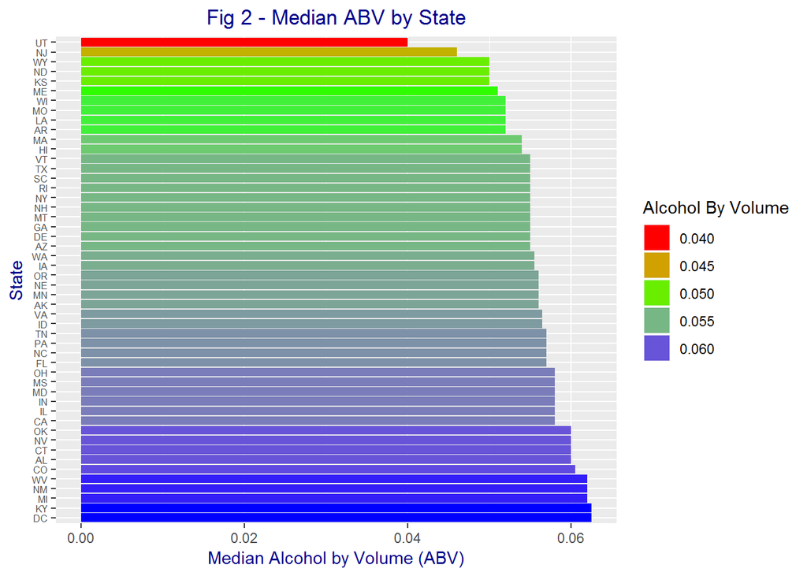

```r
#Create DF for median Alcohol by Volume (ABV) and International Bitterness Units (IBU)
#   NA's are ignored in calculations, and associated state is inlcuded in the data frame
medianABV <- aggregate(allBeerDataDF$AlcoholByVolume, list(allBeerDataDF$State), median, na.rm=TRUE)
names(medianABV) <- c("State","MedianAlcoholByVolume") # Add Column Names
medianIBU <- na.omit(aggregate(allBeerDataDF$BitternessUnits, list(allBeerDataDF$State), median, na.rm=TRUE)) # used na.omit since all SD IBUs were blank
names(medianIBU) <- c("State","MedianBitternessUnits") # Add Column Names

medianBeerData <- merge(medianABV,medianIBU,"State")   # Merge median ABV & IBU into one DF

# Plot ABV by State, flip axes for easier reading, sort by ABV, called Figure 2.
ggplot(medianBeerData) +
  aes(x=reorder(State,-MedianAlcoholByVolume),y=MedianAlcoholByVolume,fill=MedianAlcoholByVolume,na.omit=TRUE) +
  geom_bar(stat="identity") + coord_flip() +                                              # make hoizontal plot
  theme(axis.text.y=element_text(size=6)) +                                               # decrease axis font
  labs(title = "Fig 2 - Median ABV by State",x="State",y="Median Alcohol by Volume (ABV)") +# add axes titles
  theme(plot.title = element_text(color="dark blue",hjust=0.5)) +                         # format main title
  theme(axis.title.x = element_text(color="dark blue")) +                                 # format x title
  theme(axis.title.y = element_text(color="dark blue")) +                                 # format y title
  guides(fill=guide_legend("Alcohol By Volume")) +                                        # label legend
  scale_fill_gradientn(colours = rainbow(3))                                              # set color scheme
```

#### A beer’s bitterness comes from the amount of hops brewers add to beer. Higher IBUs = more hoppy beer. The range for median IBUs is roughly 20 to 60. Wisconsin, Kansas, and Arizona have craft beers with the lowest medain IBUs. Maine has the highest median IBU and West Virginia and Florida follow.

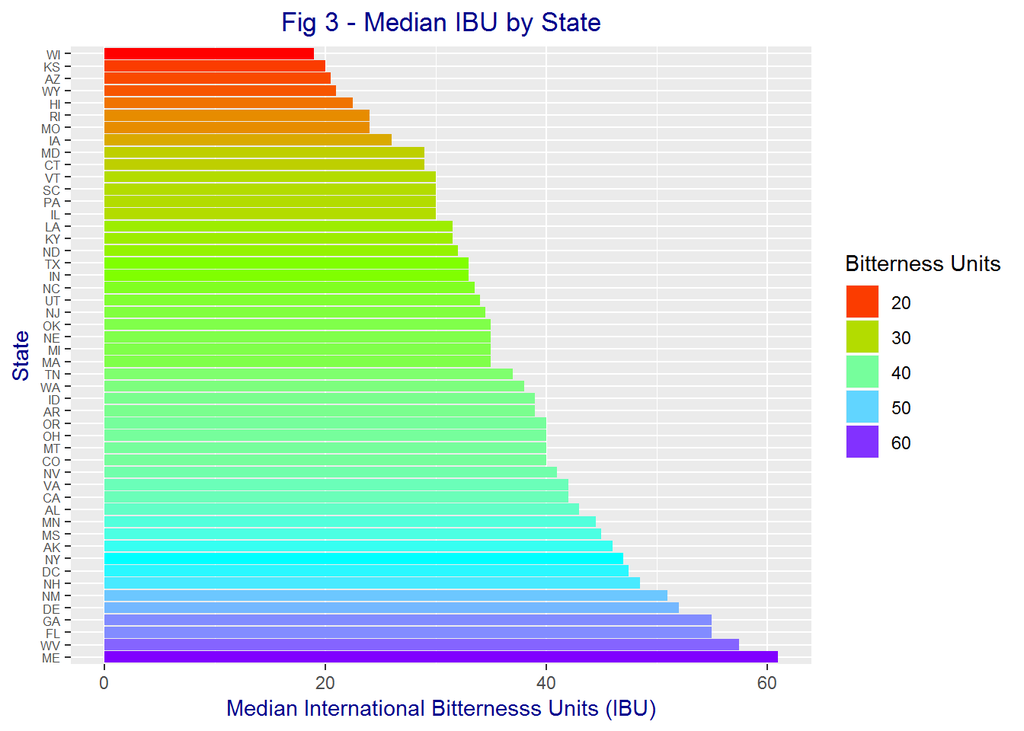

```r
# Plot IBU by State, flip axes for easier reading, sort by IBU, called Figure 3.
ggplot(medianBeerData) +
  aes(x=reorder(State,-MedianBitternessUnits),y=MedianBitternessUnits,fill=MedianBitternessUnits,na.omit=TRUE) +
  geom_bar(stat="identity") + coord_flip() +                                              # make hoizontal plot
  theme(axis.text.y=element_text(size=6)) +                                               # decrease axis font
  labs(title = "Fig 3 - Median IBU by State",x="State",y="Median International Bitternesss Units (IBU)") + # add axes titles
  theme(plot.title = element_text(color="dark blue",hjust=0.5)) +                         # format main title
  theme(axis.title.x = element_text(color="dark blue")) +                                 # format x title
  theme(axis.title.y = element_text(color="dark blue")) +                                 # format y title
  guides(fill=guide_legend("Bitterness Units")) +                                         # label legend
  scale_fill_gradientn(colours = rainbow(4))                                              # set color scheme
```

#### **Objective 5:** The which.max function was used within kable to display the beer and brewery information for the beer that had the highest ABV and highest IBU.

#### Colorado has the craft beer with the highest ABV and Oregon has the craft beer with the highest IBU.

```r
#Identifying state with max ABV (alcohol) & IBU (bitterness)

# Print Info about State with the Most Alcohol by Volume
kable(allBeerDataDF[which.max(allBeerDataDF$AlcoholByVolume),],format="html",
      caption="Table 4 - State with the Most Alcohol by Volume (ABV)",align='c',row.names=F) %>%
  kable_styling(bootstrap_options = "striped", full_width = F)
```

Table 4 - State with the Most Alcohol by Volume (ABV)

| BreweryID | BreweryName | City | State | BeerName | BeerID | AlcoholByVolume | BitternessUnits | BeerStyle | Ounces |
| --- | --- | --- | --- | --- | --- | --- | --- | --- | --- |
| 52 | Upslope Brewing Company | Boulder | CO | Lee Hill Series Vol. 5 - Belgian Style Quadrupel Ale | 2565 | 0.128 | NA | Quadrupel (Quad) | 19.2 |

```r
#The state with the maximum alcoholic beer is Colorado. It has a 0.128 ABV and comes from the Upslope Brewing Company. The beer is the Lee Hill Series Vol. 5, a Belgian Style Quadrupel Ale.

kable(allBeerDataDF[which.max(allBeerDataDF$BitternessUnits),],format="html",
      caption="Table 5 - State with the Highest International Bitterness Units (IBU)",align='c',row.names=F) %>%
  kable_styling(bootstrap_options = "striped", full_width = F)
```

Table 5 - State with the Highest International Bitterness Units (IBU)

| BreweryID | BreweryName | City | State | BeerName | BeerID | AlcoholByVolume | BitternessUnits | BeerStyle | Ounces |
| --- | --- | --- | --- | --- | --- | --- | --- | --- | --- |
| 375 | Astoria Brewing Company | Astoria | OR | Bitter Bitch Imperial IPA | 980 | 0.082 | 138 | American Double / Imperial IPA | 12 |

#### **Objective 6:** The summary function was used with kable to display summary statistics for ABV. The data was transposed to display in a horizontal format. Then a boxplot is displayed which coincides with the ABV summary statistics. The mean and median are fairly close to each other with the mean ~ 6%.

```r
# Below are the summary statistics for the Achohol By Volume (ABV)
kable(t(summary(allBeerDataDF$AlcoholByVolume)),format="html",                # used transpose function to get desired format
      caption="Table 6 - Summary Statistics for Alcohol By Volume (ABV)",align='c',row.names=F) %>%
  kable_styling(bootstrap_options = "striped", full_width = F)
```

Table 6 - Summary Statistics for Alcohol By Volume (ABV)

| Min. | 1st Qu. | Median | Mean | 3rd Qu. | Max. | NA’s |
| --- | --- | --- | --- | --- | --- | --- |
| 0.001 | 0.05 | 0.056 | 0.0597734 | 0.067 | 0.128 | 62 |

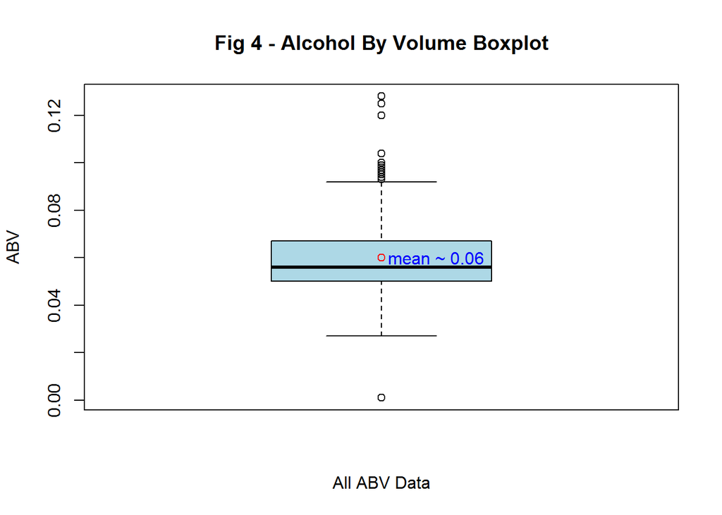

```r
boxplot(allBeerDataDF$AlcoholByVolume, main="Fig 4 - Alcohol By Volume Boxplot", xlab="All ABV Data", ylab="ABV",col="lightblue")
ABVmean<-round(mean(allBeerDataDF$AlcoholByVolume,trim=0,na.rm=TRUE),3)       # get mean ABV, ignore NA, round it
points(ABVmean,col="red")                                                     # show red pt for mean ABV
text(x=1.1, ABVmean,"mean ~ 0.06",col=4)                                      # add mean label to box plot
```

#### **Objective 7:** ggplot is once again used but this time to create a scatter plot of ABV vs IBU. Additionally, goem_smooth is used to show the linear fit for the data. The cor function was used to identify whether there is a statistically significant correlation with IBU and ABV. The code for this can be found in the Appendix section. The analysis used an alpha = 0.05. Below the plot, html tags and equation indicators are used to disply r and r-squared.

#### We can see from the slope of the linear fit that there is a positive correlation and this is confirmed with an r = 0.671. This makes r-squared = .4502 and we conclude that 45% of the variance of the data can be explained by the linear model.

#### The correlation function produces a p-value much less than the significance level of 0.05 which tells us that the correlation IS statistically significant.

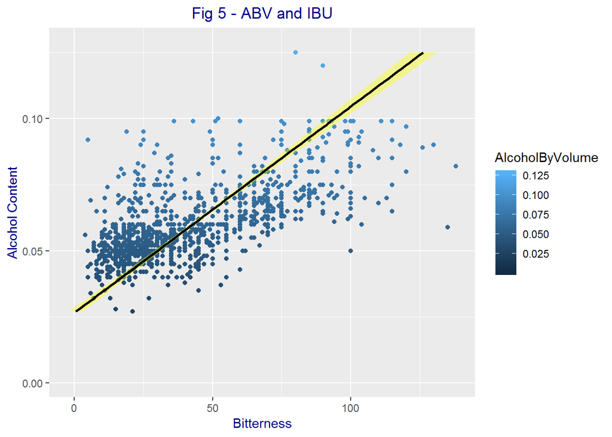

```r
#Plot ABV vs IBU and determine if there is a relationship between the two

scatterplot <- ggplot(allBeerDataDF, aes(AlcoholByVolume,BitternessUnits,col=AlcoholByVolume)) +
  geom_point() + coord_flip() +                                                             # make horizontal scatter plot
  ggtitle("Fig 5 - ABV and IBU") +                                                          # add title
  theme(plot.title = element_text(color="dark blue",hjust=0.5)) +                           # format main title
  xlab("Alcohol Content") +  ylab("Bitterness") +                                           # add axis labels
  theme(axis.title.x = element_text(color="dark blue")) +                                   # format x title
  theme(axis.title.y = element_text(color="dark blue"))                                     # format y title

#linear fit by lm to scatterplot
scatterplot+geom_smooth(method = "lm", colour = "black", fill="yellow")
```

r = 0.671, positive linear correlation
$$r^{2} = 0.4502$$

### CONCLUSIONS

#### We have succesfully demonstrated the merging, munging, and analysis of craft beer and brewery data sets. The results show a positive linear correlation and it is statistically signifcant. However, we recommned the following additional steps to obtain additional information that can provide better guidance for craft beer investments.

#### -Review various sales data on the top craft beers

#### -Utilize surveys to understand customer demand trends

#### -Host/partner events and promotions to collect our own data

#### -Analyze population trends and review brewery/alcohol laws

## Presentation Links

#### Lei’s presentation video: https://youtu.be/oOQyaFVAUDs

#### Steve’s presentation video: https://youtu.be/mxRx6X9cZ10

## Appendix

#### R-code used to perform the correlation analysis.

```r
cor.test(allBeerDataDF$AlcoholByVolume, allBeerDataDF$BitternessUnits)
```

```
##
##  Pearson's product-moment correlation
##
## data:  allBeerDataDF$AlcoholByVolume and allBeerDataDF$BitternessUnits
## t = 33.863, df = 1403, p-value < 2.2e-16
## alternative hypothesis: true correlation is not equal to 0
## 95 percent confidence interval:
##  0.6407982 0.6984238
## sample estimates:
##       cor
## 0.6706215
```

#### Interesting Map of most breweries per person. The Rocky Mountain states seem to enjoy their craft beers.

Fig - States with Most Breweries Per Person

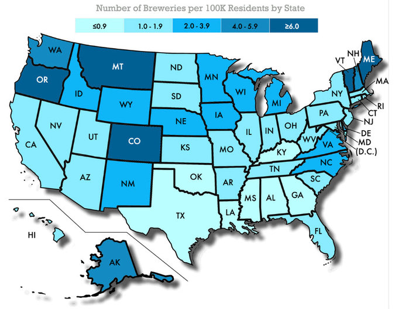

#### Top 2017 craft beers were analyzed in MS-Excel and Untappd top 10 craft beers have a median AVB =5.7% and median IBU=50

#### Ref:https://vinepair.com/booze-news/2017s-popular-craft-beers-according-untappd/